# Newton's method

The Babylonian method is an algorithm to find an approximate value for $\sqrt{k}$. It was described by the first-century Greek mathematician Hero of [Alexandria](http://en.wikipedia.org/wiki/Babylonian_method).

The method starts with some initial guess, called $x_0$. It then applies a formula to produce an improved guess. This is repeated until the improved guess is accurate enough or it is clear the algorithm fails to work.

For the Babylonian method, the next guess, $x_{i+1}$ derived from the current guess, $x_i$, is:

\[ ~ x_{i+1} = \frac{1}{2}(x_i + \frac{k}{x_i}) ~ \]

We use this algorithm to approximate the square root of $2$, a value known to the Babylonians.

Start with $x$, then form $x/2 + 1/x$, from this again form $x/2 + 1/x$, repeat.

Let's look starting with $x = 2$ as a rational number:

```julia
x = 2//1
x = x//2 + 1//x
x, x^2.0
```

```
(3//2, 2.25)
```

Our estimate improved from something which squared to $4$ down to something which squares to $2.25$. A big improvement, but there is still more to come.

```julia
x = x//2 + 1//x
x, x^2.0
```

```
(17//12, 2.0069444444444446)
```

We now see accuracy until the third decimal point.

```julia
x = x//2 + 1//x
x, x^2.0
```

```
(577//408, 2.000006007304883)
```

This is now accurate to the sixth decimal point. That is about as far as we, or the Bablyonians, would want to go by hand. Using rational numbers quickly grows out of hand. The next step shows the explosion:

```julia
x = x//2 + 1//x
```

```
665857//470832
```

However, with the advent of floating point numbers, the method stays quite manageable:

```julia
x = 2.0
x = x/2 + 1/x   # 1.5, 2.25
x = x/2 + 1/x   # 1.4166666666666665, 2.006944444444444
x = x/2 + 1/x   # 1.4142156862745097, 2.0000060073048824
x = x/2 + 1/x   # 1.4142135623746899, 2.0000000000045106
x = x/2 + 1/x   # 1.414213562373095,  1.9999999999999996
x = x/2 + 1/x   # 1.414213562373095,  1.9999999999999996
```

```
1.414213562373095
```

We see that the algorithm–-to the precision offered by floating point numbers–-has resulted in an answer `1.414213562373095`. This answer is an *approximation* to the actual answer. Approximation is necessary, as $\sqrt{2}$ is an irrational number and so can never be exactly represented in floating point. That being said, we see that the value of $f(x)$ is accurate to the last decimal place, so our approximation is very close and is achieved in a few steps.

## Newton's generalization

Let $f(x) = x^3 - 2x -5$. The value of 2 is almost a zero, but not quite, as $f(2) = -1$. We can check that there are no *rational* roots. Though there is a method to solve the cubic it may be difficult to compute and will not be as generally applicable as some algorithm like the Babylonian method to produce an approximate answer.

Is there some generalization to the Babylonian method?

That is, it seems that the intersection of the tangent line and the $x$ axis should be an improved approximation for the zero of the function.

Let $x_0$ be $2$, and $x_1$ be the intersection point of the tangent line at $(x_0, f(x_0))$ with the $x$ axis. Then by the definition of the tangent line:

\[ ~ f'(x_0) = \frac{\Delta y }{\Delta x} = \frac{f(x_0)}{x_0 - x_1}. ~ \]

This can be solved for $x_1$ to give $x_1 = x_0 - f(x_0)/f'(x_0)$. In general, if we had $x_i$ and used the intersection point of the tangent line to produce $x_{i+1}$ we would have Newton's method:

\[ ~ x_{i+1} = x_i - \frac{f(x_i)}{f'(x_i)}. ~ \]

We will use automatic derivatives, as possible, so load the `CalculusWithJulia` package which provides the `f'` notation for derivatives through the definition `Base.adjoint(f::Function)=x->ForwardDiff.derivative(f, float(x))`:

```julia
using CalculusWithJulia
```

With this, the algorithm above starting from $2$ becomes:

```julia
x0 = 2
x1 = x0 - f(x0)/f'(x0)
```

```
2.1
```

We can see we are closer to a zero:

```julia
f(x0), f(x1)
```

```
(-1, 0.06100000000000083)
```

Trying again, we have

```julia
x2 = x1 - f(x1)/ f'(x1)
x2, f(x2), f(x1)
```

```
(2.094568121104185, 0.00018572317327247845, 0.06100000000000083)
```

And again:

```julia
x3 = x2 - f(x2)/ f'(x2)
x3, f(x3), f(x2)
```

```
(2.094551481698199, 1.7397612239733462e-9, 0.00018572317327247845)
```

```julia
x4 = x3 - f(x3)/ f'(x3)
x4, f(x4), f(x3)
```

```
(2.0945514815423265, -8.881784197001252e-16, 1.7397612239733462e-9)
```

We see now that $f(x_4)$ is within machine tolerance of $0$, so we call $x_4$ an *approximate zero* of $f(x)$.

> Newton's method. Let $x_0$ be an initial guess for a zero of $f(x)$. Iteratively define $x_{i+1}$ in terms of the just generated $x_i$ by: $x_{i+1} = x_i - f(x_i) / f'(x_i)$. Then for most functions and reasonable initial guesses, the sequence of points converges to a zero of $f$.

On the computer, we know that actual convergence will likely never occur, but accuracy to a certain tolerance can often be achieved.

In the example above, we kept track of the previous values. This is unnecessary if only the answer is sought. In that case, the update step can use the same variable:

```julia
x = 2                     # x0
x = x - f(x) / f'(x)      # x1
x = x - f(x) / f'(x)      # x2
x = x - f(x) / f'(x)      # x3
x = x - f(x) / f'(x)      # x4
```

```
2.0945514815423265
```

As seen above, the assignment will update the value bound to `x` using the previous value of `x` in the computation.

We implement the algorithm by repeating the step until either we converge or it is clear we won't converge. For good guesses and most functions, convergence happens quickly.

Newton looked at this same example in 1699 (B.T. Polyak, *Newton's method and its use in optimization*, European Journal of Operational Research. 02/2007; 181(3):1086-1096.) though his technique was slightly different as he did not use the derivative, *per se*, but rather an approximation based on the fact that his function was a polynomial (though identical to the derivative). Raphson (1690) proposed the general form, hence the usual name of the Newton-Raphson method.

## Examples

##### Example: visualizing convergence

This graphic demonstrates the method and the rapid convergence:

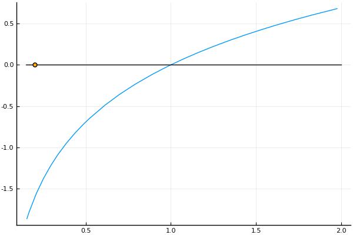

Illustration of Newton's Method converging to a zero of a function.

##### Example: numeric not algebraic

For the function $f(x) = \cos(x) - x$, we see that SymPy can not solve symbolically for a zero:

```julia
@vars x real=true
solve(cos(x) - x, x)
```

[output not shown]

We can find a numeric solution, even though there is no closed-form answer. Here we try Newton's method:

```julia
f(x) = cos(x) - x
x = .5
x = x - f(x)/f'(x)  # 0.7552224171056364
x = x - f(x)/f'(x)  # 0.7391416661498792
x = x - f(x)/f'(x)  # 0.7390851339208068
x = x - f(x)/f'(x)  # 0.7390851332151607
x = x - f(x)/f'(x)
```

```
0.7390851332151607
```

This answer is close, to machine tolerance it produces $0.0$:

```julia
x, f(x)
```

```
(0.7390851332151607, 0.0)
```

##### Example division as multiplication

[Newton-Raphson Division](http://tinyurl.com/kjj9w92) is a means to divide by multiplying.

Why would you want to do that? Well, even for computers division is harder (read slower) than multiplying. The trick is that $p/q$ is simply $p \cdot (1/q)$, so finding a means to compute a reciprocal by multiplying will reduce division to multiplication. (This trick is used by [yeppp](http://www.yeppp.info/resources/ppam-presentation.pdf), a high performance library for computational mathematics.)

Well suppose we have $q$, we could try to use Newton's method to find $1/q$, as it is a solution to $f(x) = x - 1/q$. The Newton update step simplifies to:

\[ ~ x - f(x) / f'(x) \quad\text{or}\quad x - (x - 1/q)/ 1 = 1/q ~ \]

That doesn't really help, as Newton's method is just $x_{i+1} = 1/q$ – that is it just jumps to the answer, the one we want to compute by some other means!

Trying again, we simplify the update step for a related function: $f(x) = 1/x - q$ with $f'(x) = -1/x^2$ and then one step of the process is:

\[ ~ x_{i+1} = x_i - (1/x_i - q)/(-1/x_i^2) = -qx^2_i + 2x_i. ~ \]

Now for $q$ in the interval $[1/2, 1]$ we want to get a *good* initial guess. Here is a claim. We can use $x_0=48/17 - 32/17 \cdot q$. Let's check graphically that this is a reasonable initial approximation to $1/q$:

```julia
g(q) = 1/q
h(q) = 1/17 * (48 - 32q)
plot(g, 1/2, 1)
plot!(h)
```

[output not shown]

It can be shown that we have for any $q$ in $[1/2, 1]$ with initial guess $x_0 = 48/17 - 32/17\cdot q$ that Newton's method will converge to 16 digits in no more than this many steps:

\[ ~ \log_2(\frac{53 + 1}{\log_2(17)}). ~ \]

```julia
a = log2((53 + 1)/log2(17))
ceil(Integer, a)
```

```
4
```

That is 4 steps suffices.

For $q = 0.80$, to find $1/q$ using the above we have

```julia
q = 0.80
x = (48/17) - (32/17)*q
x = -q*x*x + 2*x
x = -q*x*x + 2*x
x = -q*x*x + 2*x
x = -q*x*x + 2*x
```

```
1.25
```

This method has basically $18$ multiplication and addition operations for one division, so it naively would seem slower, but timing this shows the method is competitive with a regular division.

## A function

In the previous example, a bound ensures convergence in 4 steps. In general, this is not the case with Newton's method where the algorithm is iterated until convergence. Having to repeat steps until something happens is a task best done by the computer. The `while` loop is a good way to repeat commands until some condition is met. With this, we present a simple function implementing Newton's method, we iterate until the update step gets really small (the `delta`) or the convergence takes more than 50 steps. (There are other reasonable choices that could be used to determine when the algorithm should stop.)

```julia
function nm(f, fp, x0)
  tol = 1e-14
  ctr = 0
  delta = Inf
  while (abs(delta) > tol) & (ctr < 50)
    delta = f(x0)/fp(x0)
    x0 = x0 - delta
    ctr = ctr + 1
  end

  ctr < 50 ? x0 : NaN
end
```

```
nm (generic function with 1 method)
```

##### Examples

- Find a zero of $\sin(x)$ starting at $x_0=3$:

```julia
nm(sin, cos, 3)
```

```
3.141592653589793
```

This is an approximation for $\pi$, that historically found use, as the convergence is fast.

- Find a solution to $x^5 = 5^x$ near $2$:

Writing a function to handle this, we have:

```julia
f(x) = x^5 - 5^x
```

```
f (generic function with 1 method)
```

```julia
alpha = nm(f, f', 2)
alpha, f(alpha)
```

```
(1.764921914525776, 0.0)
```

### Functions in the Roots package

Typing in the `nm` function might be okay once, but would be tedious if it was needed each time. The `Roots` package provides a `Newton` method. `Roots` is loaded with

```julia
using Roots
find_zero((sin, cos), 3, Roots.Newton())  # alternatively Roots.newton(sin,cos, 3)
```

```
3.141592653589793
```

Or, if a derivative is not specified, one can be computed using automatic differentiation:

```julia
find_zero((f, f'), 2, Roots.Newton())
```

```
1.764921914525776
```

The argument `verbose=true` will force a print out of a message summarizing each step.

More generally, the function `find_zero` provides a derivative-free algorithm for finding roots of functions, when started with an initial guess. It is similar to Newton's method in that only a good initial guess is needed. However, the algorithm, while slower in terms of function evaluations and steps, is engineered to be a bit more robust to the choice of initial estimate than Newton's method. (If it finds a bracket, it will use a bisection algorithm which is guaranteed to converge, but can be slower to do so.) Here we see how to call the function:

```julia
f(x) = cos(x) - x
x0 = 1
find_zero(f, x0)
```

```
0.7390851332151607
```

Compare to this related call which uses the bisection method:

```julia
find_zero(f, (0, 1))           ## [0,1] must be a bracketing interval
```

```
0.7390851332151607
```

For this example both give the same answer, but the bisection method is a bit more inconvenient as a bracketing interval must be pre-specified.

##### Example: intersection of two graphs

Find the intersection point between $f(x) = \cos(x)$ and $g(x) = 5x$ near $0$.

We have Newton's method to solve for zeros of $f(x)$, i.e. when $f(x) = 0$. Here we want to solve for $x$ with $f(x) = g(x)$. To do so, we make a new function $h(x) = f(x) - g(x)$, for that is $0$ when $f(x)$ equals $g(x)$:

```julia
f(x) = cos(x)
g(x) = 5x
h(x) = f(x) - g(x)
x0 = find_zero((h,h'), 0, Roots.Newton())
x0, h(x0), f(x0), g(x0)
```

```
(0.19616428118784215, 0.0, 0.9808214059392107, 0.9808214059392107)
```

##### Example: Finding $c$ in Rolle's Theorem

The function $f(x) = \sqrt{1 - \cos(x^2)^2}$ has a zero at $0$ and one near 1.77.

```julia
f(x) = sqrt(1 - cos(x^2)^2)
plot(f, 0, 1.77)
```

[output not shown]

As $f(x)$ is differentiable between $0$ and $a$, Rolle's theorem says there will be value where the derivative is $0$. Find that value.

This value will be a zero of the derivative. A graph shows it should be near $1.2$, so we use that as a starting value to get the answer:

```julia
find_zero(f', 1.2)
```

```
1.2533141373155003
```

## Convergence

Newton's method is famously known to have "quadratic convergence." What does this mean? Let the error in the $i$th step be called $e_i = x_i - \alpha$. Then Newton's method satisfies a bound of the type:

\[ ~ \lvert e_{i+1} \rvert \leq M_i \cdot e_i^2. ~ \]

If $M$ were just a constant and we suppose $e_0 = 10^{-1}$ then $e_1$ would be less than $M 10^{-2}$ and $e_2$ less than $M^2 10^{-4}$, $e_3$ less than $M^3 10^{-8}$ and $e_4$ less than $M^4 10^{-16}$ which for $M=1$ is basically the machine precision. That is for some problems, with a good initial guess it will take around 4 or so steps to converge.

The actual value of $M$ depends on $i$ and $f$, so the answer isn't always so easy. To see what $M$ is, the basic assumption of $f$ is such that this fact of linearization holds at each $x_i$ with $f(x_i) \neq 0$:

\[ ~ f(x) = f(x_i) + f'(x_i) \cdot (x - x_i) + \frac{1}{2} f''(\xi) \cdot (x-x_i)^2. ~ \]

The value $\xi$ is from the mean value theorem and is between $x$ and $x_i$.

Let $x=\alpha$, the zero of $f(x)$ that is being sought. Then $f(\alpha)=0$ and $0=f(x_i)/f'(x_i) + (\alpha-x_i) + 1/2\cdot f''(\xi)/f'(x_i) \cdot (\alpha-x_i)^2$. For this value, we have

\[ ~ x_{i+1} - \alpha = x_i - \frac{f(x_i)}{f'(x_i)} - \alpha = (x_i - \alpha) + (\alpha - x_i) + \frac{1}{2}\frac{f''(\xi) \cdot(\alpha - x_i)^2}{f'(x_i)} = \frac{1}{2}\frac{f''(\xi)}{f'(x_i)} \cdot(x_i - \alpha)^2. ~ \]

That is

\[ ~ \lvert e_{i+1}\rvert \leq \frac{1}{2}\frac{\lvert f''(\xi)\rvert}{\lvert f'(x_i)\rvert} e_i^2. ~ \]

This convergence will be quadratic *if*:

- The initial guess $x_0$ is not too far from $\alpha$, so $e_0$ is managed.
- The derivative at $x_i$ is not too close to $0$. (As it appears in the denominator). That is, the function can't be too flat, which should make sense, as then the tangent line is nearly parallel to the $x$ axis and would intersect far away.
- The second derivative is not too big (in absolute value) near the zero. A large second derivative means the function is very concave, which means it is "turning" a lot. In this case, the function turns away from the tangent line quickly, so the tangent line's zero is not necessarily a better approximation to the actual zero, $\alpha$.

The basic tradeoff: methods like Newton's are faster than the bisection method in terms of function calls, but are not guaranteed to converge, as the bisection method is.

What can go wrong when one of these isn't the case is illustrated next:

### Poor initial step

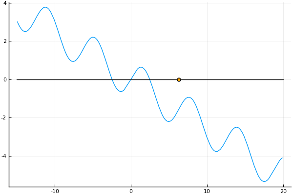

Illustration of Newton's Method converging to a zero of a function, but slowly as the initial guess, is very poor, and not close to the zero. The algorithm does converge in this illustration, but not quickly and not to the nearest root from the initial guess.

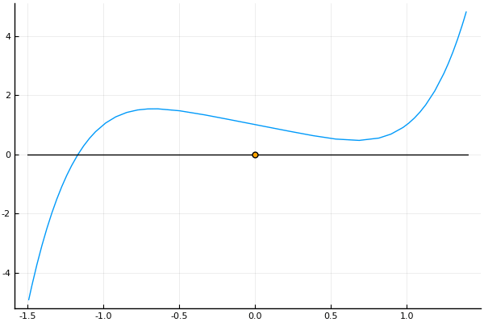

Illustration of Newton's method failing to coverge as for some $x_i$, $f'(x_i)$ is too close to 0. In this instance after a few steps, the algorithm just cycles around the local minimum near $0.66$. The values of $x_i$ repeat in the pattern: $1.0002, 0.7503, -0.0833, 1.0002, \dots$. This is also an illustration of a poor initial guess. If there is a local minimum or maximum between the guess and the zero, such cycles can occur.

### The second derivative is too big

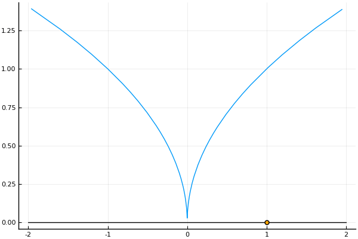

Illustration of Newton's Method not converging. Here the second derivative is too big near the zero – it blows up near $0$ – and the convergence does not occur. Rather the iterates increase in their distance from the zero.

### The tangent line at some $x_i$ is flat

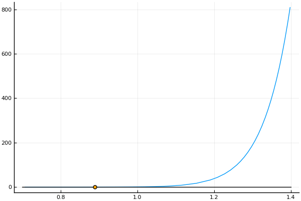

The function $f(x) = x^{20} - 1$ has two bad behaviours for Newton's method: for $x < 1$ the derivative is nearly $0$ and for $x>1$ the second derivative is very big. In this illustration, we have an initial guess of $x_0=8/9$. As the tangent line is fairly flat, the next approximation is far away, $x_1 = 1.313\dots$. As this guess is is much bigger than $1$, the ratio $f(x)/f'(x) \approx x^{20}/(20x^{19}) = x/20$, so $x_i - x_{i-1} \approx (19/20)x_i$ yielding slow, linear convergence until $f''(x_i)$ is moderate. For this function, starting at $x_0=8/9$ takes 11 steps, at $x_0=7/8$ takes 13 steps, at $x_0=3/4$ takes 55 steps, and at $x_0=1/2$ it takes $204$ steps.

###### Example

Suppose $\alpha$ is a simple zero for $f(x)$. (The value $\alpha$ is a zero of multiplicity $k$ if $f(x) = (x-\alpha)^kg(x)$ where $g(\alpha)$ is not zero.) A simple zero has multiplicity $1$. If $f'(\alpha) \neq 0$ and the second derivative exists, then a zero $\alpha$ will be simple.) Around $\alpha$, quadratic convergence should apply. However, consider the function $g(x) = f(x)^k$ for some integer $k \geq 2$. Then $\alpha$ is still a zero, but the derivative of $g$ at $\alpha$ is zero, so the tangent line is basically flat. This will slow the convergence up. We can see that the update step $g'(x)/g(x)$ becomes $(1/k) f'(x)/f(x)$, so an extra factor is introduced.

The calculation that produces the quadratic convergence now becomes:

\[ ~ x_{i+1} - \alpha = (x_i - \alpha) - \frac{1}{k}(x_i-\alpha + \frac{f''(\xi)}{2f'(x_i)}(x_i-\alpha)^2) = \frac{k-1}{k} (x_i-\alpha) + \frac{f''(\xi)}{2kf'(x_i)}(x_i-\alpha)^2. ~ \]

As $k > 1$, the $(x_i - \alpha)$ term dominates, and we see the convergence is linear with $\lvert e_{i+1}\rvert \approx (k-1)/k \lvert e_i\rvert$.

## Questions

###### Question

$-2.224$

$-2.80$

$-0.020$

$0.355$

###### Question

What can be said about $x_1$?

It must be $x_0 < x_1 < c$

It must be $x_1 < x_0$

It must be $x_1 > c$

###### Question

What can be said about $x_1$?

It must be $x_1 > x_0$

It must be $c < x_1 < x_0$

It must be $x_1 < c$

###### Question

Suppose $f(x)$ is concave up and we have the tangent line representation: $f(x) = f(c) + f'(c)\cdot(x-c) + f''(\xi)/2 \cdot(x-c)^2$. Explain why it must be that the graph of $f(x)$ lies on or *above* the tangent line.

As $f''(\xi)/2 \cdot(x-c)^2$ is non-negative, we must have $f(x) - (f(c) + f'(c)\cdot(x-c)) \geq 0$.

This isn't true. The function $f(x) = x^3$ at $x=0$ provides a counterexample

As $f''(\xi) < 0$ it must be that $f(x) - (f(c) + f'(c)\cdot(x-c)) \geq 0$.

###### Question

Let $f(x) = x^2 - 3^x$. This has derivative $2x - 3^x \cdot \log(3)$. Starting with $x_0=0$, what does Newton's method converge on?

###### Question

Let $f(x) = \exp(x) - x^4$. There are 3 zeros for this function. Which one does Newton's method converge to when $x_0=2$?

###### Question

Let $f(x) = \exp(x) - x^4$. As mentioned, there are 3 zeros for this function. Which one does Newton's method converge to when $x_0=8$?

###### Question

Let $f(x) = \sin(x) - \cos(4\cdot x)$.

Starting at $\pi/8$, solve for the root returned by Newton's method

###### Question

Using Newton's method find a root to $f(x) = \cos(x) - x^3$ starting at $x_0 = 1/2$.

###### Question

Use Newton's method to find a root of $f(x) = x^5 + x -1$. Make a quick graph to find a reasonable starting point.

###### Question

Will Newton's method converge for the function $f(x) = x^5 - x + 1$ starting at $x=1$?

Yes

No. The initial guess is not close enough

No. The second derivative is too big

No. The first derivative gets too close to $0$ for one of the $x_i$

###### Question

Will Newton's method converge for the function $f(x) = 4x^5 - x + 1$ starting at $x=1$?

Yes

No. The initial guess is not close enough

No. The second derivative is too big, or does not exist

No. The first derivative gets too close to $0$ for one of the $x_i$

###### Question

Will Newton's method converge for the function $f(x) = x^{10} - 2x^3 - x + 1$ starting from $0.25$?

Yes

No. The initial guess is not close enough

No. The second derivative is too big, or does not exist

No. The first derivative gets too close to $0$ for one of the $x_i$

###### Question

Will Newton's method converge for $f(x) = 20x/(100 x^2 + 1)$ starting at $0.1$?

Yes

No. The initial guess is not close enough

No. The second derivative is too big, or does not exist

No. The first derivative gets too close to $0$ for one of the $x_i$

###### Question

Will Newton's method converge to a zero for $f(x) = \sqrt{(1 - x^2)^2}$?

Yes

No. The initial guess is not close enough

No. The second derivative is too big, or does not exist

No. The first derivative gets too close to $0$ for one of the $x_i$

###### Question

Use `find_zero` to find a root of $f(x) = 4x^4 - 5x^3 + 4x^2 -20x -6$ starting at $x_0 = 0$.

###### Question

Use `find_zero` to find a zero of $f(x) = \sin(x) - x/2$ that is *bigger* than $0$.